# presentation

WM_ASDS19 · BIG DATA · SECTION A · SPRING 2026

Large-Scale Analysis and Prediction of Building Electricity Consumption

Using Weather and Building Characteristics

Group name: **Data Explorers**

Md. Fahad Rahman (20251702) · Anik Halder (20251703)  
Md. Sohel Rana (20251717) · Md. Ashikul Islam Shohag (20251739)

Submitted to: Farhana Akter Bina, Associate Professor  
Department of Statistics & Data Science, Jahangirnagar University

## The problem and dataset

Can building characteristics, time and weather improve hourly electricity prediction at scale?

20.22 M

Raw training meter readings

12.06 M

Electricity readings (meter 0)

11.15 M

Retained after excluding Site 0

### Project objectives

- Process large-scale meter and weather data.
- Identify temporal and building-level patterns.
- Predict electricity use and assess the benefit of weather features.

### Data source

ASHRAE Great Energy Predictor III

**Approximately 2.43 GB** across CSV files; 2016 training readings, building metadata and weather observations.

## Big Data processing architecture

Two independent preprocessing implementations; one primary analytical workflow.

**Raw CSV files**

Meter readings · building metadata · weather

PRIMARY

**DuckDB**

Filter · join · aggregate

REPRODUCTION

**PySpark**

Independent preprocessing

**Parquet**

Model-ready data → LightGBM

**9 / 9 checks matched**

Dataset-level consistency checks

Join keys: building ID for metadata; site ID and timestamp for weather.

## What does electricity use depend on?

### Hour of day

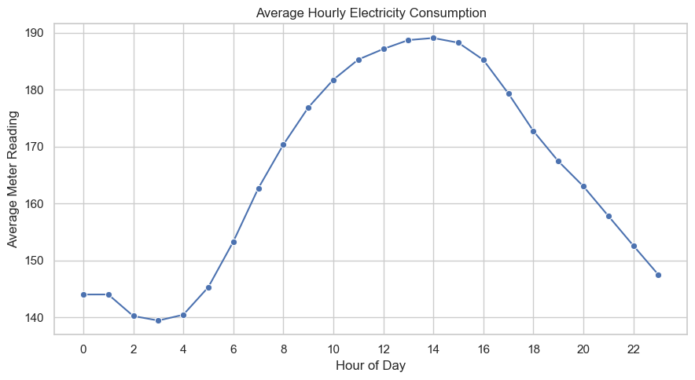

### Outdoor temperature

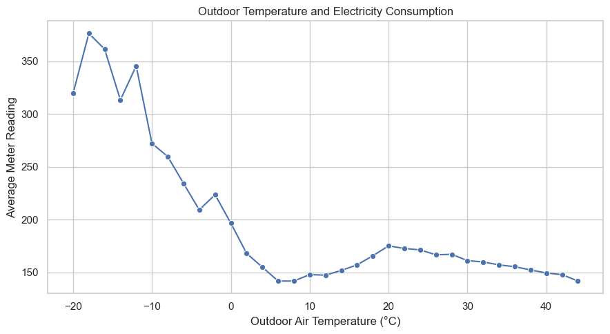

These analyses motivate time and weather features; building characteristics provide additional context.

## Predictive modeling

### Three prediction approaches

1. Historical building-hour median baseline
2. LightGBM without weather
3. LightGBM with weather

**Building (4):** ID, site, primary use, floor area  
**Time (3):** hour, weekday, month  
**Weather (3):** air temperature, dew point, wind speed

### Chronological holdout

74.6%

16.9%

8.5%

| Set | Period (2016) | Rows |
| --- | --- | --- |
| Train | Jan–Sep | 8.32 M |
| Validation | Oct–Nov | 1.89 M |
| Test | Dec | 0.94 M |

**Metrics:** MAE and RMSLE

Both LightGBM models: 200 rounds, learning rate 0.05, 31 leaves; log-transformed target $\ln(1+y)$.

## Weather features improved validation accuracy

### Validation · Oct–Nov

| Approach | MAE | RMSLE |
| --- | --- | --- |
| Baseline | 38.67 | 0.867 |
| LGBM, no weather | 41.04 | 0.723 |
| **LGBM + weather** | **35.93** | **0.694** |

### Test · December

| Approach | MAE | RMSLE |
| --- | --- | --- |
| Baseline | 44.91 | 0.776 |
| **LGBM + weather** | **41.09** | **0.625** |

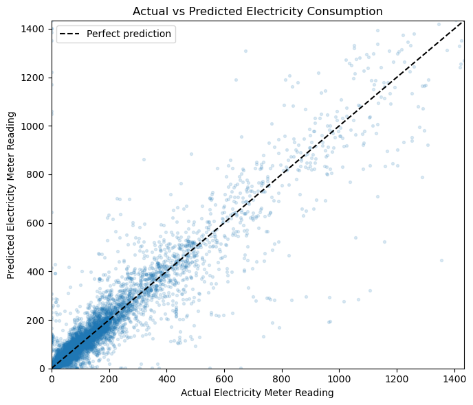

19.5% lower test RMSLE versus baseline

Validation: adding weather reduced MAE by about 12.5% and RMSLE by 4.0% relative to LightGBM without weather.

## Conclusion

11.15 million retained electricity readings

Processed into a model-ready dataset, with independent PySpark consistency checks.

### Key outcomes

- Scalable DuckDB and Parquet workflow
- Weather improved validation accuracy
- December test RMSLE: **0.6245**

### Limitations and application

- Electricity only; Site 0 excluded
- Generalization beyond December 2016 untested
- Potential use: flag persistent deviations for facilities review

Thank you · Questions & discussion